# Prediction of Housing Prices in Toronto

Group: NoName2

Setare Setarenejad & Amir Soltan Mohammadlue

## 1. Introduction

The main goal of this project is to develop a machine learning model to predict housing prices in Toronto. This project could be useful for real estates as well as investors in housing market. In recent years especially under the shadow of COVID-19 pandemic, the housing prices have experienced considerable fluctuations. Housing prices plunged by the closure of businesses and eventually rocketed up during the re-openings. These unusual factors changed the routine behaviour of the real state market. In this project we tried to develop a model based on recent years’ data to estimate Housing prices in Toronto according to new trends which is based on specific selected features plus the effect of neighbourhood in Toronto. Datasets in this project includes:

1. Housing dataset
2. GTA neighbourhoods’ geographical dataset
3. Neighbourhood profiles’ dataset

## 2. Notebook Setup:

```python
# Load dependencies
import warnings
warnings.filterwarnings('ignore')
import pandas as pd
import numpy as np
import pandas as pd
import matplotlib.pyplot as plt
import statsmodels.api as sm
import urllib.request
import time
import bs4 as bs
# from geopy.geocoders import Nominatim
!pip install geopandas
import geopandas as gpd
import seaborn as sns
from scipy import stats
import re

from shapely.geometry import Point, Polygon
from tqdm import tqdm

# Set directory
import os
path = os.getcwd()
os.chdir(path)

# Set the sns style
%matplotlib inline
# sns.reset_defaults()
# sns.set(
#     rc={'figure.figsize':(15,8)},
#     style="white"
# )
sns.set_context('talk')
sns.set_style("whitegrid")
```

## 3. The Housing Dataset

File 'raw_data_Zolo.xlsx' includes data for each houses in Toronto included Title, Price, Type of property, Exact address, Bedrooms, Bathrooms, Sqft, Parking, Age, Yearly taxation, Maintenance Fees, Latitude and Longitude.

```python
# Configure Notebook
%matplotlib inline
plt.style.use('fivethirtyeight')
!pip install openpyxl
# sns.set_context("notebook")
```

```python
zolo_data = pd.read_excel('raw_data_Zolo.xlsx', index_col=0)
zolo_data.head()
```

|  | title | final_price | list_price | bedrooms | bathrooms | sqft | parking | full_link | full_address | postal_code | lat | long | type | Sold on | style | age | tax | maintenance |
| --- | --- | --- | --- | --- | --- | --- | --- | --- | --- | --- | --- | --- | --- | --- | --- | --- | --- | --- |
| 0 | 57 - 270 Timberbank Boulevard | NaN | $699888.00 | 3.0 | 3.0 | 1400-1599 sqft | NaN | https://www.zolo.ca/toronto-real-estate/270-ti... | 270 Timberbank boulevard, Toronto | M1W2M1 | 43.7969 | -79.3075 | Townhouse | Mar 14, 2022 | 2-Storey | No Data | $2,188 /yr | \n$529 /mo |
| 1 | 26 King Edward Avenue | NaN | $929000.00 | 3.0 | 2.0 | No Data | NaN | https://www.zolo.ca/toronto-real-estate/26-kin... | 26 King Edward avenue, Toronto | M4C5J6 | 43.6884 | -79.3108 | Semi-Detached | Mar 14, 2022 | 2-Storey | No Data | $3,355 /yr | NaN |
| 2 | 77 Ridgecrest Drive | NaN | $1899000.00 | 4.0 | 5.0 | No Data | NaN | https://www.zolo.ca/toronto-real-estate/77-rid... | 77 Ridgecrest Drive, Toronto | M1W4A3 | 43.7882 | -79.3166 | Detached | Mar 13, 2022 | 2-Storey | No Data | $5,743 /yr | NaN |
| 3 | 24 Marlebon Road | NaN | $999900.00 | 3.0 | 2.0 | 1500-2000 sqft | NaN | https://www.zolo.ca/toronto-real-estate/24-mar... | 24 Marlebon road, Toronto | M9V3W2 | 43.7490 | -79.6034 | Detached | Mar 14, 2022 | Sidesplit 3 | No Data | $3,147 /yr | NaN |
| 4 | 34 Ferris Road | NaN | $1199000.00 | 2.0 | 2.0 | 700-1100 sqft | NaN | https://www.zolo.ca/toronto-real-estate/34-fer... | 34 Ferris road, Toronto | M4B1G3 | 43.7013 | -79.3082 | Detached | Mar 14, 2022 | Bungalow-Raised | No Data | $4,063 /yr | NaN |

```python
zolo_data.shape
```

```
(16903, 18)
```

The raw dataset contains 16,903 data of the sold houses in the city of Toronto.

## 4. Data Cleaning

Since the initial data included Nan values and outliers, a data cleaning procedure was required to clean the data.

Let's see how many null values exist in the dataset.

```python
zolo_data.isnull().sum()
```

```
title            1577
final_price     16903
list_price       1591
bedrooms         1591
bathrooms        1592
sqft             1655
parking         16903
full_link           0
full_address     1976
postal_code      1976
lat              1976
long             1976
type             1591
Sold on          1655
style            1655
age              1655
tax              1655
maintenance      7820
dtype: int64
```

To simplify the data analysis, all of the data with missing values were dropped.

```python
zolo_data.dropna(subset=['list_price'], inplace=True)
zolo_data.dropna(subset=['lat'], inplace=True)
zolo_data.dropna(subset=['long'], inplace=True)
zolo_data.dropna(subset=['Sold on'], inplace=True)
zolo_data.dropna(subset=['full_address'], inplace=True)
zolo_data['sqft'].replace({'No Data': None}, inplace=True)
zolo_data.dropna(subset=['sqft'], inplace=True)
zolo_data.drop(['maintenance'], axis=1, inplace=True)

zolo_data.isnull().sum()
```

```
title               0
final_price     10781
list_price          0
bedrooms            0
bathrooms           0
sqft                0
parking         10781
full_link           0
full_address        0
postal_code         0
lat                 0
long                0
type                0
Sold on             0
style               0
age                 0
tax                 0
dtype: int64
```

```python
zolo_data.shape
```

```
(10781, 17)
```

After dropping the missing values, the data shrunk by 6,000 However there are still more than 10,000 cases which can be useful for modeling. The next step of cleaning was removing punctuations and clarifying the definition of numeric values:

The next step, would be to remove the punctuations and extract the numeric values from collected stings.

```python
zolo_data['list_price'] = [int(row.replace('$', '').replace('.00','')) for row in zolo_data['list_price']]
zolo_data['sqft'] = [row.replace('sqft', '').replace('+', '').replace('<','') for row in zolo_data['sqft']]
zolo_data['sqft_min'] = [int(row.split('-')[0]) for row in zolo_data['sqft']]
zolo_data['sqft_max'] = [int(row.split('-')[-1]) for row in zolo_data['sqft']]
zolo_data['sqft_avg'] = (zolo_data['sqft_max'] + zolo_data['sqft_min'])/2
zolo_data['Sold on'] = pd.to_datetime(zolo_data['Sold on'])
zolo_data = zolo_data[zolo_data['bathrooms']<10]
zolo_data.drop(['final_price', 'parking'], axis=1, inplace=True)
```

There were numerous names for same type of properties in the dataset. The different entry names for property type were unified in the dataset.

```python
zolo_data['style'].unique()
```

```
array(['2-Storey', 'Sidesplit 3', 'Bungalow-Raised', 'Apartment',
       'Multi-Level', 'Stacked Townhse', '3-Storey', '2 1/2 Storey',
       'Bungalow', 'Loft', 'Bachelor/Studio', 'Other', 'Sidesplit 4',
       'Backsplit 4', 'Backsplit 3', '1 1/2 Storey', 'Backsplit 5',
       'Bungaloft', 'Sidesplit 5'], dtype=object)
```

Now another column will be added that for example if the style of the property was apartment, multi-level or Bachelor/Studio, those styles were unified as apartment.

```python
zolo_data['style'] = zolo_data['style'].replace(to_replace= ['Apartment','Multi-Level', 'Bachelor/Studio'], value= 'Apt')
zolo_data['style'] = zolo_data['style'].replace(['2-Storey', 'Stacked Townhse', '3-Storey', '2 1/2 Storey', '1 1/2 Storey'], 'house')
zolo_data['style'] = zolo_data['style'].replace(['Sidesplit 3', 'Bungalow-Raised', 'Bungalow', 'Loft', 'Sidesplit 4', 'Backsplit 4', 'Backsplit 3', '1 1/2 Storey', 'Backsplit 5','Bungaloft', 'Sidesplit 5'], 'detached')
```

```python
zolo_data['style'].unique()
```

```
array(['house', 'detached', 'Apt', 'Other'], dtype=object)
```

Let's save the clean dataset for future use.

```python
zolo_data.to_csv('cleaned_zolo.csv', index=False)
```

## 5. Data Wrangling

The purpose of merging different datasets was to add income, area name and area code features to the housing dataset.

To eliminate the duplicate values in dataset, the duplicates are dropped based on the `full_link` attribute.

```python
houses = pd.read_csv('cleaned_zolo.csv', index_col=0)
houses
```

| title | list_price | bedrooms | bathrooms | sqft | full_link | full_address | postal_code | lat | long | type | Sold on | style | age | tax | sqft_min | sqft_max | sqft_avg |
| --- | --- | --- | --- | --- | --- | --- | --- | --- | --- | --- | --- | --- | --- | --- | --- | --- | --- |
| 57 - 270 Timberbank Boulevard | 699888 | 3.0 | 3.0 | 1400-1599 | https://www.zolo.ca/toronto-real-estate/270-ti... | 270 Timberbank boulevard, Toronto | M1W2M1 | 43.7969 | -79.3075 | Townhouse | 2022-03-14 | house | No Data | $2,188 /yr | 1400 | 1599 | 1499.5 |
| 24 Marlebon Road | 999900 | 3.0 | 2.0 | 1500-2000 | https://www.zolo.ca/toronto-real-estate/24-mar... | 24 Marlebon road, Toronto | M9V3W2 | 43.7490 | -79.6034 | Detached | 2022-03-14 | detached | No Data | $3,147 /yr | 1500 | 2000 | 1750.0 |
| 34 Ferris Road | 1199000 | 2.0 | 2.0 | 700-1100 | https://www.zolo.ca/toronto-real-estate/34-fer... | 34 Ferris road, Toronto | M4B1G3 | 43.7013 | -79.3082 | Detached | 2022-03-14 | detached | No Data | $4,063 /yr | 700 | 1100 | 900.0 |
| Ph37 - 300 Mill Road | 949000 | 3.0 | 3.0 | 1800-1999 | https://www.zolo.ca/toronto-real-estate/300-mi... | 300 Mill road, Toronto | M9C4W7 | 43.6387 | -79.5843 | Condo | 2022-03-14 | house | No Data | $3,080 /yr | 1800 | 1999 | 1899.5 |
| 1611 - 31 Tippett Road | 899000 | 2.0 | 2.0 | 800-899 | https://www.zolo.ca/toronto-real-estate/31-tip... | 31 Tippett road, Toronto M | 3H 0C8 | 43.7335 | -79.4461 | Condo | 2022-03-14 | Apt | No Data | No Data | 800 | 899 | 849.5 |
| ... | ... | ... | ... | ... | ... | ... | ... | ... | ... | ... | ... | ... | ... | ... | ... | ... | ... |
| 1924 - 80 Harrison Garden Boulevard | 539900 | 1.0 | 1.0 | 500-599 | https://www.zolo.ca/toronto-real-estate/80-har... | 80 Harrison Garden boulevard, Toronto | M2N7E3 | 43.7561 | -79.4064 | Condo | 2021-09-18 | Apt | No Data | $1,784 /yr | 500 | 599 | 549.5 |
| Ph02 - 1331 Queen Street | 1399000 | 2.0 | 2.0 | 1000-1199 | https://www.zolo.ca/toronto-real-estate/1331-q... | 1331 Queen street, Toronto | M4M1K9 | 43.6639 | -79.3266 | Condo | 2021-09-19 | Apt | No Data | No Data | 1000 | 1199 | 1099.5 |
| 1509 - 7 Michael Power Place | 469900 | 1.0 | 1.0 | 500-599 | https://www.zolo.ca/toronto-real-estate/7-mich... | 7 Michael Power place, Toronto | M9A0A4 | 43.6444 | -79.5296 | Comm Element Condo | 2021-09-19 | Apt | No Data | $1,558 /yr | 500 | 599 | 549.5 |
| 410 - 236 Albion Road | 469000 | 3.0 | 2.0 | 1000-1199 | https://www.zolo.ca/toronto-real-estate/236-al... | 236 Albion road, Toronto | M9W6A6 | 43.7220 | -79.5440 | Condo | 2021-09-20 | Apt | No Data | $747 /yr | 1000 | 1199 | 1099.5 |
| 1012 - 195 Bonis Avenue | 555000 | 2.0 | 2.0 | 800-899 | https://www.zolo.ca/toronto-real-estate/195-bo... | 195 Bonis avenue, Toronto | M1T3W6 | 43.7859 | -79.2919 | Condo | 2021-09-19 | Apt | No Data | $2,236 /yr | 800 | 899 | 849.5 |

10703 rows × 17 columns

```python
houses.drop_duplicates(subset=['full_link'], inplace=True)
```

The ultimate goal is to assign each house data with the mean income of their corresponding neighbourhood.

The neighbourhood profiles database file used in this project was created in 2016 and contains detailed information about education, ethnicity, immigration/citizenship, income, population, etc. in different neighbourhoods. Merging the neighbourhood profile data with the housing data, provides the possibility to assign the mean income of the corresponding neighbourhood to other housing dataset features. In this project, “income data” and “area codes/names” features from the `neighbourhood profiles` were used.

```python
# Get Toronto neighbourhood data and extract district codes with their average incomes
t_data = pd.read_csv('neighbourhood-profiles-2016-csv.csv')

t_income = t_data[(t_data.Characteristic == 'Neighbourhood Number') | (t_data.Characteristic == 'Total income: Average amount ($)')]
t_income = t_income.T.reset_index()

t_income.columns = ['area', 'area_code', 'average_income']
t_income = t_income.iloc[6:,:]
print(t_income.head())
print('-' * 60)

# convert income and area into integers
print(t_income.info())
print('-' * 60)
t_income['average_income'] = t_income['average_income'].apply(lambda a: a.replace(',','')).astype('int64')
t_income['area_code'] = t_income['area_code'].astype('int64')
print(t_income.info())
print('-' * 60)

# Calculate incoem mean
mean_t_income = t_income['average_income'].mean()
print('GTA mean income: ',mean_t_income)
```

```
                            area area_code average_income
6                Agincourt North       129         30,414
7   Agincourt South-Malvern West       128         31,825
8                      Alderwood        20         47,709
9                          Annex        95        112,766
10             Banbury-Don Mills        42         67,757
------------------------------------------------------------
<class 'pandas.core.frame.DataFrame'>
RangeIndex: 140 entries, 6 to 145
Data columns (total 3 columns):
 #   Column          Non-Null Count  Dtype
---  ------          --------------  -----
 0   area            140 non-null    object
 1   area_code       140 non-null    object
 2   average_income  140 non-null    object
dtypes: object(3)
memory usage: 3.4+ KB
None
------------------------------------------------------------
<class 'pandas.core.frame.DataFrame'>
RangeIndex: 140 entries, 6 to 145
Data columns (total 3 columns):
 #   Column          Non-Null Count  Dtype
---  ------          --------------  -----
 0   area            140 non-null    object
 1   area_code       140 non-null    int64
 2   average_income  140 non-null    int64
dtypes: int64(2), object(1)
memory usage: 3.4+ KB
None
------------------------------------------------------------
GTA mean income:  55248.49285714285
```

In order to merge the income data with housing dataset, it should be specified that each listed property is in which neighbourhood area. To do this, latitude and longitude of properties were used to create a geometry point object (Coordinate Reference System: EPSG:4269).

```python
# Use gpd.GeoDataFrame() to create a GeoDataFrame from houses and assign the new GeoDataFrame to a new variable called houses_gdf.
houses_gdf = gpd.GeoDataFrame(houses, geometry=gpd.points_from_xy(houses.long, houses.lat))
houses_gdf.head()
```

| title | list_price | bedrooms | bathrooms | sqft | full_link | full_address | postal_code | lat | long | type | Sold on | style | age | tax | sqft_min | sqft_max | sqft_avg | geometry |
| --- | --- | --- | --- | --- | --- | --- | --- | --- | --- | --- | --- | --- | --- | --- | --- | --- | --- | --- |
| 57 - 270 Timberbank Boulevard | 699888 | 3.0 | 3.0 | 1400-1599 | https://www.zolo.ca/toronto-real-estate/270-ti... | 270 Timberbank boulevard, Toronto | M1W2M1 | 43.7969 | -79.3075 | Townhouse | 2022-03-14 | house | No Data | $2,188 /yr | 1400 | 1599 | 1499.5 | POINT (-79.30750 43.79690) |
| 24 Marlebon Road | 999900 | 3.0 | 2.0 | 1500-2000 | https://www.zolo.ca/toronto-real-estate/24-mar... | 24 Marlebon road, Toronto | M9V3W2 | 43.7490 | -79.6034 | Detached | 2022-03-14 | detached | No Data | $3,147 /yr | 1500 | 2000 | 1750.0 | POINT (-79.60340 43.74900) |
| 34 Ferris Road | 1199000 | 2.0 | 2.0 | 700-1100 | https://www.zolo.ca/toronto-real-estate/34-fer... | 34 Ferris road, Toronto | M4B1G3 | 43.7013 | -79.3082 | Detached | 2022-03-14 | detached | No Data | $4,063 /yr | 700 | 1100 | 900.0 | POINT (-79.30820 43.70130) |
| Ph37 - 300 Mill Road | 949000 | 3.0 | 3.0 | 1800-1999 | https://www.zolo.ca/toronto-real-estate/300-mi... | 300 Mill road, Toronto | M9C4W7 | 43.6387 | -79.5843 | Condo | 2022-03-14 | house | No Data | $3,080 /yr | 1800 | 1999 | 1899.5 | POINT (-79.58430 43.63870) |
| 1611 - 31 Tippett Road | 899000 | 2.0 | 2.0 | 800-899 | https://www.zolo.ca/toronto-real-estate/31-tip... | 31 Tippett road, Toronto M | 3H 0C8 | 43.7335 | -79.4461 | Condo | 2022-03-14 | Apt | No Data | No Data | 800 | 899 | 849.5 | POINT (-79.44610 43.73350) |

The neighbourhood map is downloaded from “City of Toronto” and converted from the original Shapefile format to `t_geodata dataset` (CRS: EPSG:4269).

```python
#Obtaining neighbourhood locations and shapes from Open Data Portal and converting them from their original Shapefile format to a more manageable one.
#Using EPSG:4269 (Lat, Long format) in this case we’ll ensure that the coordinates align for both areas and properties.
t_geodata = gpd.read_file('Neighbourhoods.shp')

# rename columns
t_geodata_columns = pd.read_csv('Neighbourhoods_fields.csv')
t_geodata.columns = t_geodata_columns.name.values

# Convert data to lat, long type
t_geodata['geometry'] = t_geodata['geometry'].to_crs({'init': 'EPSG:4326'})
t_geodata.head()
```

|  | _id | AREA_ID | AREA_ATTR_ID | PARENT_AREA_ID | AREA_SHORT_CODE | AREA_LONG_CODE | AREA_NAME | AREA_DESC | X | Y | LONGITUDE | LATITUDE | OBJECTID | Shape__Area | Shape__Length | geometry |
| --- | --- | --- | --- | --- | --- | --- | --- | --- | --- | --- | --- | --- | --- | --- | --- | --- |
| 0 | 141 | 25886861 | 25926662 | 49885 | 94 | 94 | Wychwood (94) | Wychwood (94) | None | None | -79.425515 | 43.676919 | 16491505 | 3.217960e+06 | 7515.779658 | POLYGON ((-79.43592 43.68015, -79.43492 43.680... |
| 1 | 142 | 25886820 | 25926663 | 49885 | 100 | 100 | Yonge-Eglinton (100) | Yonge-Eglinton (100) | None | None | -79.403590 | 43.704689 | 16491521 | 3.160334e+06 | 7872.021074 | POLYGON ((-79.41096 43.70408, -79.40962 43.704... |
| 2 | 143 | 25886834 | 25926664 | 49885 | 97 | 97 | Yonge-St.Clair (97) | Yonge-St.Clair (97) | None | None | -79.397871 | 43.687859 | 16491537 | 2.222464e+06 | 8130.411276 | POLYGON ((-79.39119 43.68108, -79.39141 43.680... |
| 3 | 144 | 25886593 | 25926665 | 49885 | 27 | 27 | York University Heights (27) | York University Heights (27) | None | None | -79.488883 | 43.765736 | 16491553 | 2.541821e+07 | 25632.335242 | POLYGON ((-79.50529 43.75987, -79.50488 43.759... |
| 4 | 145 | 25886688 | 25926666 | 49885 | 31 | 31 | Yorkdale-Glen Park (31) | Yorkdale-Glen Park (31) | None | None | -79.457108 | 43.714672 | 16491569 | 1.156669e+07 | 13953.408098 | POLYGON ((-79.43969 43.70561, -79.44011 43.705... |

“t_geodata” and “t_income” were merged based on “area_shore_code” and “area_code” in two datasets, respectively to a `all_t_data` dataframe.

```python
# Merge districts geodata and Toronto income

all_t_data = t_geodata.merge(t_income, left_on='AREA_SHORT_CODE', right_on='area_code')
useless_columns_all_t_data = ['_id', 'AREA_ID', 'AREA_ATTR_ID', 'PARENT_AREA_ID', 'AREA_SHORT_CODE', 'AREA_LONG_CODE',
                             'AREA_NAME', 'AREA_DESC', 'X', 'Y','LONGITUDE','LATITUDE']
all_t_data.drop(useless_columns_all_t_data, axis=1, inplace=True)
all_t_data.to_csv('all_t_data.csv')
all_t_data.head()
```

|  | OBJECTID | Shape__Area | Shape__Length | geometry | area | area_code | average_income |
| --- | --- | --- | --- | --- | --- | --- | --- |
| 0 | 16491505 | 3.217960e+06 | 7515.779658 | POLYGON ((-79.43592 43.68015, -79.43492 43.680... | Wychwood | 94 | 54460 |
| 1 | 16491521 | 3.160334e+06 | 7872.021074 | POLYGON ((-79.41096 43.70408, -79.40962 43.704... | Yonge-Eglinton | 100 | 89330 |
| 2 | 16491537 | 2.222464e+06 | 8130.411276 | POLYGON ((-79.39119 43.68108, -79.39141 43.680... | Yonge-St.Clair | 97 | 114174 |
| 3 | 16491553 | 2.541821e+07 | 25632.335242 | POLYGON ((-79.50529 43.75987, -79.50488 43.759... | York University Heights | 27 | 29958 |
| 4 | 16491569 | 1.156669e+07 | 13953.408098 | POLYGON ((-79.43969 43.70561, -79.44011 43.705... | Yorkdale-Glen Park | 31 | 38527 |

```python
from shapely.geometry import Point, Polygon
from tqdm import tqdm

def find_district(point, df):
    '''
    Returns District name, Area code, and District average income
    '''

    in_shape = []
    for sh in df.geometry:
        within = point.within(sh)
        in_shape.append(within)
    return df.loc[in_shape.index(True), 'area'], df.loc[in_shape.index(True), 'area_code'], df.loc[in_shape.index(True), 'average_income']


houses['mean_district_income'] = 0
houses['district_code'] = 0

not_assigned = []
for row, value in tqdm(houses.iterrows()):
    try:
        result = find_district(Point(houses.loc[row, 'long'], houses.loc[row, 'lat']), all_t_data)
        houses.loc[row, 'city_district'] = result[0]
        houses.loc[row, 'mean_district_income'] = result[2]
        houses.loc[row, 'district_code'] = result[1]
        time.sleep(0.1)
    except:
        not_assigned.append(row)

# Not assigned houses
print(not_assigned)
```

```
10671it [23:05,  7.70it/s]
```

```
['1202 - 1275 Markham Road', '317 - 1050 Main Street East Street', '1202 - 1275 Markham Road', '17 Kenwood Drive']
```

```python
houses.to_csv('houses_with_income.csv')
```

## 6. Exploratory Data Analysis

Let's start the data examination from `Distribution of Income in GTA` and `Distribution of Housing Price in GTA`.

```python
houses_income = pd.read_csv('houses_with_income.csv', index_col='title')
all_t_data = pd.read_csv('all_t_data.csv', index_col= 'Unnamed: 0')
```

The following graph which shows the average square feet versus listing price shows a meaningful correlation in our dataset.

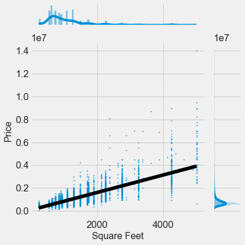

```python
ax = sns.jointplot(data=zolo_data, x="sqft_avg", y="list_price", kind="reg",
              joint_kws={'line_kws':{'color':'k'}}, scatter_kws={'s': 1})

ax.set_axis_labels('Square Feet', 'Price', fontsize=16)

ax.figure.tight_layout()
```

Following graph shows number of listings per area.

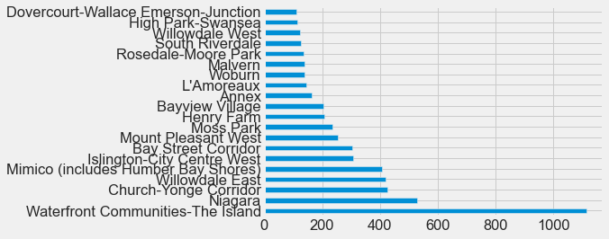

```python
houses_income['city_district'].value_counts()[:20].plot(kind='barh')
```

```python
my_columns = ['lat','long','style','bedrooms','bathrooms','mean_district_income','list_price','sqft_avg']
features = list(set(my_columns))
Map_toronto=houses_income[features]
Map_toronto.shape
```

```
(10671, 8)
```

```python
Map_toronto['size']=Map_toronto['bedrooms']+Map_toronto['bathrooms']
```

```python
Map_toronto.loc[Map_toronto['size'] > 10] = 10
Map_toronto.head(5)
```

| title | bathrooms | bedrooms | sqft_avg | long | style | list_price | mean_district_income | lat | size |
| --- | --- | --- | --- | --- | --- | --- | --- | --- | --- |
| 57 - 270 Timberbank Boulevard | 3.0 | 3.0 | 1499.5 | -79.3075 | house | 699888 | 31826 | 43.7969 | 6.0 |
| 24 Marlebon Road | 2.0 | 3.0 | 1750.0 | -79.6034 | detached | 999900 | 31771 | 43.7490 | 5.0 |
| 34 Ferris Road | 2.0 | 2.0 | 900.0 | -79.3082 | detached | 1199000 | 43907 | 43.7013 | 4.0 |
| Ph37 - 300 Mill Road | 3.0 | 3.0 | 1899.5 | -79.5843 | house | 949000 | 62378 | 43.6387 | 6.0 |
| 1611 - 31 Tippett Road | 2.0 | 2.0 | 849.5 | -79.4461 | Apt | 899000 | 51181 | 43.7335 | 4.0 |

In the following figure size is number of bathroom + number of bedroom, and the distribution of list price and avarge area of a place is plotted with respect to number of rooms in the house( markers are size indicators).

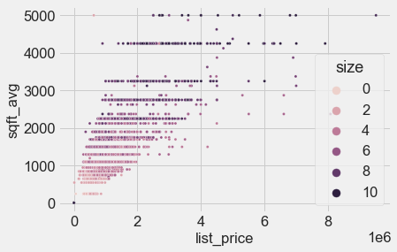

```python
sns.scatterplot(data=Map_toronto, x="list_price",y="sqft_avg",hue="size" ,s=10)
```

Map of Toronto base on the listing price.

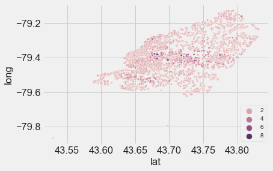

```python
Map_toronto = Map_toronto[Map_toronto['long'] <= 0]
sns.scatterplot(data=Map_toronto, x="lat", y="long",hue="list_price", s=10)
plt.legend(loc='lower right',fontsize=10)
```

Map of Toronto base on the income of owners.

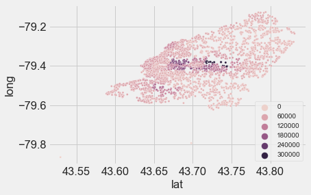

```python
sns.scatterplot(data=Map_toronto, x="lat", y="long", hue="mean_district_income", s=10)
plt.legend(loc='lower right',fontsize=10)
```

The distribution of Apt detached and houses:

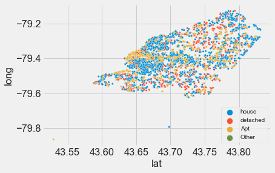

```python
sns.scatterplot(data=Map_toronto, x="lat", y="long", hue="style", s=10)
plt.legend(loc='lower right',fontsize=10)
```

```python
houses_income.head(2)
```

| title | list_price | bedrooms | bathrooms | sqft | full_link | full_address | postal_code | lat | long | type | ... | style | age | tax | sqft_min | sqft_max | sqft_avg | geometry | mean_district_income | district_code | city_district |
| --- | --- | --- | --- | --- | --- | --- | --- | --- | --- | --- | --- | --- | --- | --- | --- | --- | --- | --- | --- | --- | --- |
| 57 - 270 Timberbank Boulevard | 699888 | 3.0 | 3.0 | 1400-1599 | https://www.zolo.ca/toronto-real-estate/270-ti... | 270 Timberbank boulevard, Toronto | M1W2M1 | 43.7969 | -79.3075 | Townhouse | ... | house | No Data | $2,188 /yr | 1400 | 1599 | 1499.5 | POINT (-79.3075 43.7969) | 31826 | 117 | L'Amoreaux |
| 24 Marlebon Road | 999900 | 3.0 | 2.0 | 1500-2000 | https://www.zolo.ca/toronto-real-estate/24-mar... | 24 Marlebon road, Toronto | M9V3W2 | 43.7490 | -79.6034 | Detached | ... | detached | No Data | $3,147 /yr | 1500 | 2000 | 1750.0 | POINT (-79.6034 43.749) | 31771 | 1 | West Humber-Clairville |

2 rows × 21 columns

```python
mean_Price = houses_income.groupby('city_district')['list_price','mean_district_income'].mean().reset_index()
mean_Price_highList=mean_Price.sort_values('list_price', ascending=False)[:15]
```

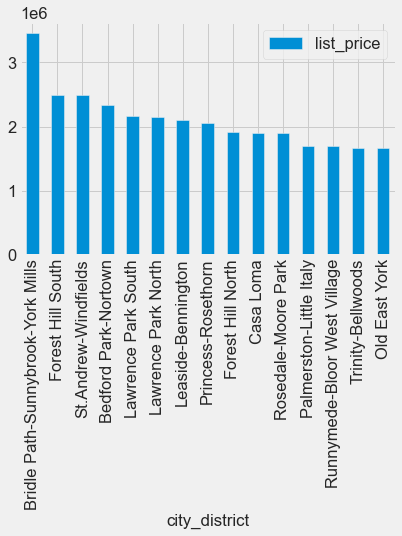

```python
ax= mean_Price_highList.plot.bar(x='city_district',y='list_price',rot=90)
```

To further explore the data, let's plot a scatterplot of the above mentioned feature.

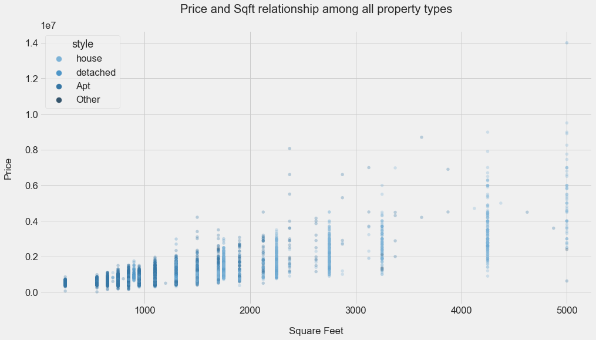

```python
# Check how final_price and sqft are related to each other among all property types
# sns.set_style("whitegrid")
plt.figure(figsize=[15,8])

ax = sns.scatterplot(x='sqft_avg', y='list_price' ,data=houses_income, hue = houses_income['style'],
                linewidth=0, alpha=0.3, palette="Blues_d", s=30)

plt.xlabel('Square Feet', labelpad=20)
plt.ylabel('Price', labelpad=20)
plt.title('Price and Sqft relationship among all property types', pad=30)
plt.show()
```

The following graphs show the distribution of income in GTA and distribution of housing price.

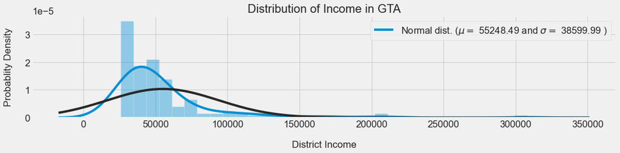

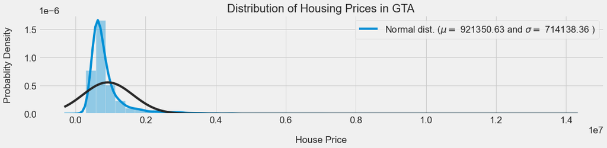

```python
plt.figure(1, figsize=[16,3])

plt.subplots_adjust(hspace=0.4)
ax = sns.distplot(all_t_data['average_income'],fit=stats.norm)
plt.xlabel('District Income', labelpad=20)
plt.ylabel('Probablity Density', labelpad=20)
plt.title('Distribution of Income in GTA')
(mu, sigma) = stats.norm.fit(all_t_data['average_income'])
plt.legend(['Normal dist. ($\mu=$ {:.2f} and $\sigma=$ {:.2f} )'.format(mu, sigma)],
            loc='best')

plt.figure(2, figsize=[16,3])

ax = sns.distplot(houses_income['list_price'],fit=stats.norm)
plt.xlabel('House Price', labelpad=20)
plt.ylabel('Probablity Density', labelpad=20)
plt.title('Distribution of Housing Prices in GTA')
(mu, sigma) = stats.norm.fit(houses_income['list_price'])
plt.legend(['Normal dist. ($\mu=$ {:.2f} and $\sigma=$ {:.2f} )'.format(mu, sigma)],
            loc='best')

plt.show()
```

The Prices and Income data are positively skewed which probably affect results on the map. However, normality is an important assumption for many statistical techniques. We decided to explore the **scipy.stats** package in order to find an appropriate power transformer.

A Box Cox transformation is a transformation of non-normal variable into a normal variable. The Box Cox transformation is based on 1964 paper of George Box and Sir David Roxbee Cox who developed the technique.

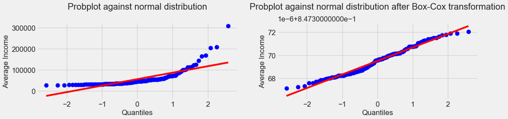

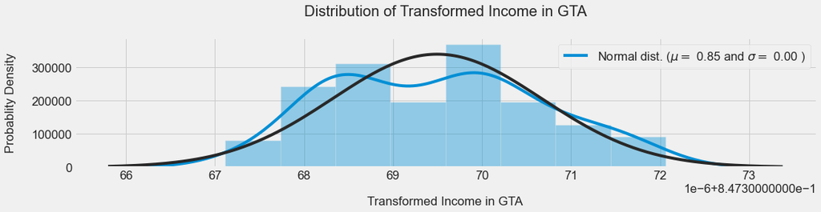

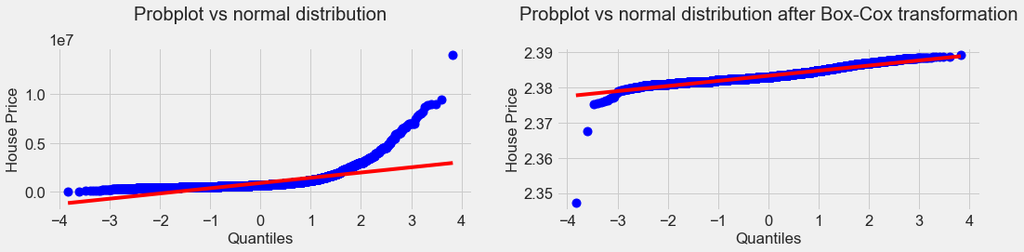

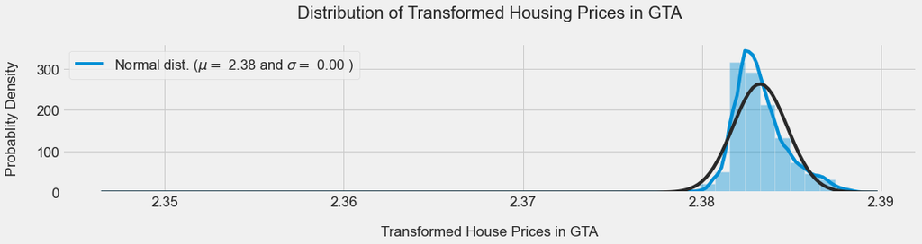

```python
plt.figure(1, figsize=[16,3])

ax1=plt.subplot(1,2,1)
x = all_t_data['average_income']
stats.probplot(x, dist=stats.norm, plot=ax1)
ax1.set_xlabel('Quantiles')
ax1.set_ylabel('Average Income')
ax1.set_title('Probplot against normal distribution', pad=30)


ax2=plt.subplot(1,2,2)
boxcox_lambda = stats.boxcox_normmax(x, brack=(-1.9, 2.0),  method='mle')
transformed_array = stats.boxcox(x, boxcox_lambda)
stats.probplot(transformed_array, dist=stats.norm , plot=ax2)
ax2.set_xlabel('Quantiles')
ax2.set_ylabel('Average Income')
ax2.set_title('Probplot against normal distribution after Box-Cox transformation', pad=30)

# transform data
all_t_data['average_income_transformed'] = transformed_array
# To transform back
# np.exp(np.log(boxcox_lambda*transformed_array+1)/boxcox_lambda)

plt.figure(2, figsize=[16,3])
sns.distplot(all_t_data['average_income_transformed'], fit=stats.norm)
plt.title('Distribution of Transformed Income in GTA', pad=30)
plt.xlabel('Transformed Income in GTA', labelpad=20)
plt.ylabel('Probablity Density', labelpad=20)
(mu, sigma) = stats.norm.fit(all_t_data['average_income_transformed'])
plt.legend(['Normal dist. ($\mu=$ {:.2f} and $\sigma=$ {:.2f} )'.format(mu, sigma)],
            loc='best')

plt.figure(3, figsize=[16,3])

ax3=plt.subplot(1,2,1)
x = houses_income['list_price']
stats.probplot(x, dist=stats.norm, plot=ax3)
ax3.set_xlabel('Quantiles')
ax3.set_ylabel('House Price')
ax3.set_title('Probplot vs normal distribution', pad=30)


ax4=plt.subplot(1,2,2)
boxcox_lambda = stats.boxcox_normmax(x, brack=(-1.9, 2.0),  method='mle')
transformed_array = stats.boxcox(x, boxcox_lambda)
stats.probplot(transformed_array, dist=stats.norm , plot=ax4)
ax4.set_xlabel('Quantiles')
ax4.set_ylabel('House Price')
ax4.set_title('Probplot vs normal distribution after Box-Cox transformation', pad=30)

houses_income['final_price_transformed'] = transformed_array

plt.figure(4, figsize=[16,3])
sns.distplot(houses_income['final_price_transformed'], fit=stats.norm)
plt.xlabel('Transformed House Prices in GTA', labelpad=20)
plt.ylabel('Probablity Density', labelpad=20)
plt.title('Distribution of Transformed Housing Prices in GTA', pad=30)
(mu, sigma) = stats.norm.fit(houses_income['final_price_transformed'])
plt.legend(['Normal dist. ($\mu=$ {:.2f} and $\sigma=$ {:.2f} )'.format(mu, sigma)],
            loc='best')


all_t_data['average_income_log']= np.log(all_t_data['average_income'])
houses_income['final_price_log']= np.log(houses_income['list_price'])


plt.show()
```

```python
houses_income.to_csv('houses_with_income.csv')
```

## 6. Data Pre-processing

In addition, the month from the “Sold_on” was extracted and added as a separate column to the dataset (“month_sold”).

```python
houses_income = pd.read_csv('houses_with_income.csv', index_col='title')
```

```python
# extract month_sold
houses_income['month_sold'] = pd.to_datetime(houses_income['Sold on'],  errors='coerce').dt.month
```

There were numerous ‘No Data’ entries in the tax column, and all of them were replaced with zeros. And this will be addressed during imputation.

```python
# clean tax colmun
houses_income['tax'] = houses_income['tax'].str.strip().str.replace('$','').str.replace(',','').str.replace(' /yr','').str.replace('No Data', '0').astype(int)
```

The categorical columns need to be one-hot-encoded. A one-hot is a group of bits among which the legal combinations of values are only those with a single high (1) bit and all the others low (0).

```python
needed_columns = ['list_price','bedrooms', 'bathrooms', 'style',
                  'tax','month_sold', 'sqft_avg', 'mean_district_income']

houses_dummies = pd.get_dummies(houses_income[needed_columns])
#houses_dummies = houses_dummies[houses_dummies.notna()]
houses_dummies
```

| title | list_price | bedrooms | bathrooms | tax | month_sold | sqft_avg | mean_district_income | style_Apt | style_Other | style_detached | style_house |
| --- | --- | --- | --- | --- | --- | --- | --- | --- | --- | --- | --- |
| 57 - 270 Timberbank Boulevard | 699888 | 3.0 | 3.0 | 2188 | 3 | 1499.5 | 31826 | 0 | 0 | 0 | 1 |
| 24 Marlebon Road | 999900 | 3.0 | 2.0 | 3147 | 3 | 1750.0 | 31771 | 0 | 0 | 1 | 0 |
| 34 Ferris Road | 1199000 | 2.0 | 2.0 | 4063 | 3 | 900.0 | 43907 | 0 | 0 | 1 | 0 |
| Ph37 - 300 Mill Road | 949000 | 3.0 | 3.0 | 3080 | 3 | 1899.5 | 62378 | 0 | 0 | 0 | 1 |
| 1611 - 31 Tippett Road | 899000 | 2.0 | 2.0 | 0 | 3 | 849.5 | 51181 | 1 | 0 | 0 | 0 |
| ... | ... | ... | ... | ... | ... | ... | ... | ... | ... | ... | ... |
| 1924 - 80 Harrison Garden Boulevard | 539900 | 1.0 | 1.0 | 1784 | 9 | 549.5 | 45326 | 1 | 0 | 0 | 0 |
| Ph02 - 1331 Queen Street | 1399000 | 2.0 | 2.0 | 0 | 9 | 1099.5 | 46206 | 1 | 0 | 0 | 0 |
| 1509 - 7 Michael Power Place | 469900 | 1.0 | 1.0 | 1558 | 9 | 549.5 | 52787 | 1 | 0 | 0 | 0 |
| 410 - 236 Albion Road | 469000 | 3.0 | 2.0 | 747 | 9 | 1099.5 | 32012 | 1 | 0 | 0 | 0 |
| 1012 - 195 Bonis Avenue | 555000 | 2.0 | 2.0 | 2236 | 9 | 849.5 | 34200 | 1 | 0 | 0 | 0 |

10671 rows × 11 columns

To determine which features are most significant for the analysis, there are various techniques. In this project, ExtraTreesRegressor function was used.

```python
features = houses_dummies.drop('list_price', axis=1)
labels = houses_dummies[['list_price']]
```

```python
features.isnull().sum()
```

```
bedrooms                0
bathrooms               0
tax                     0
month_sold              0
sqft_avg                0
mean_district_income    0
style_Apt               0
style_Other             0
style_detached          0
style_house             0
dtype: int64
```

```python
labels.isnull().sum()
```

```
list_price    0
dtype: int64
```

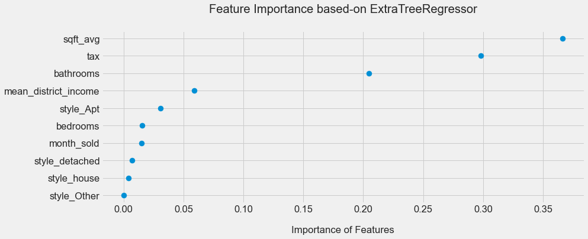

```python
from sklearn.ensemble import ExtraTreesRegressor

# sns.set_style("whitegrid")
plt.figure(figsize=[13,5])
model = ExtraTreesRegressor(n_estimators=10)
model.fit(features, labels)

# display the relative importance of each attribute
sorted_feature_importance = sorted(zip(model.feature_importances_, features.columns))

x = [a[0] for a in sorted_feature_importance]
y = [a[1] for a in sorted_feature_importance]

plt.scatter(x,y)
plt.xlabel('Importance of Features', labelpad=20)
plt.title('Feature Importance based-on ExtraTreeRegressor', pad=30)
plt.show()
```

This graph shows that according to ExtraTreesRegressor function, the most effective feature is sqft_avg. The other most important feature is tax. Since there were some missing tax values which were replaced with zero, the result of model could be adversely affected by these zero values. It is important to make better estimations on this features. KNN Imputer was used to estimate the missing values of taxes (replaced by zero) based on nearest neighbour properties.

```python
# load original house_income data
houses_income = pd.read_csv('houses_with_income.csv', index_col='title')

# extract months of sold
houses_income['month_sold'] = pd.to_datetime(houses_income['Sold on'],  errors='coerce').dt.month
# clean the tax column
houses_income['tax'] = houses_income['tax'].str.strip().str.replace('$','').str.replace(',','').str.replace(' /yr','')
# replace "No Data" with Nan in tax column
for index, row in houses_income.iterrows():
    if row['tax'] == 'No Data':
        houses_income.loc[index, 'tax'] = np.nan
    else:
        try:
            houses_income.loc[index, 'tax'] = float(row['tax'])
        except:
            print(row['tax'])

# convert categorical features
dummies_columns = ['list_price', 'bedrooms', 'bathrooms', 'style', 'sqft_avg', 'mean_district_income','month_sold']
#, 'month_sold'

houses_dummies = pd.get_dummies(houses_income[dummies_columns])
houses_dummies['tax'] = houses_income['tax']
houses_dummies.head()
```

| title | list_price | bedrooms | bathrooms | sqft_avg | mean_district_income | month_sold | style_Apt | style_Other | style_detached | style_house | tax |
| --- | --- | --- | --- | --- | --- | --- | --- | --- | --- | --- | --- |
| 57 - 270 Timberbank Boulevard | 699888 | 3.0 | 3.0 | 1499.5 | 31826 | 3 | 0 | 0 | 0 | 1 | 2188.0 |
| 24 Marlebon Road | 999900 | 3.0 | 2.0 | 1750.0 | 31771 | 3 | 0 | 0 | 1 | 0 | 3147.0 |
| 34 Ferris Road | 1199000 | 2.0 | 2.0 | 900.0 | 43907 | 3 | 0 | 0 | 1 | 0 | 4063.0 |
| Ph37 - 300 Mill Road | 949000 | 3.0 | 3.0 | 1899.5 | 62378 | 3 | 0 | 0 | 0 | 1 | 3080.0 |
| 1611 - 31 Tippett Road | 899000 | 2.0 | 2.0 | 849.5 | 51181 | 3 | 1 | 0 | 0 | 0 | NaN |

The following graph shows the distribution of bedrooms in our dataset.

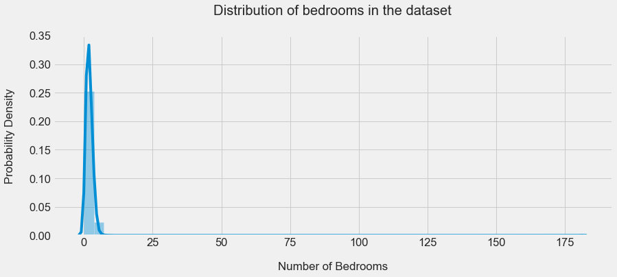

```python
# Distribution of bedrooms in dataset
plt.figure(figsize=[13,5])

ax = sns.distplot(houses_dummies['bedrooms'], hist=True)

plt.title('Distribution of bedrooms in the dataset', pad=30)
plt.ylabel('Probability Density', labelpad=20)
plt.xlabel('Number of Bedrooms', labelpad=20)
plt.show()
```

It is clear that there are lots of outliers. To handle these outliers, `Quantile-based discretization` function was used. By doing so, the bedrooms are categorized into 1, 2, 3, or more bedrooms.

```python
houses_dummies['bedrooms'] = pd.qcut(houses_dummies['bedrooms'], 4, labels=[1,2,3,4])
```

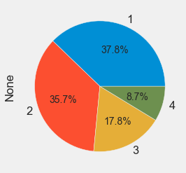

```python
houses_dummies_count = houses_dummies.value_counts('bedrooms')
houses_dummies_count.plot(kind='pie',autopct='%1.1f%%')
```

### Train, and Test split

To train a prediction model, it is critical to have at least two seperate train and validation dataset. To get that, we are using the sklearn `train_test_split` here.

```python
from sklearn.model_selection import train_test_split

X_train, X_test, y_train, y_test = train_test_split(houses_dummies.drop('list_price', axis=1), houses_dummies['list_price'], train_size=0.7)
print(f'Training dataset size:\nX_train: {X_train.shape},\ny_train: {y_train.shape}\n')
print(f'Test dataset size:\nX_test: {X_test.shape},\ny_test: {y_test.shape}')
```

```
Training dataset size:
X_train: (7469, 10),
y_train: (7469,)

Test dataset size:
X_test: (3202, 10),
y_test: (3202,)
```

### Imputing missing values in `tax`

This step has to be done after test and train set were chosen to avoide leakage.

```python
from sklearn.impute import KNNImputer

imputer = KNNImputer(n_neighbors=2, weights="uniform")
X_train['tax'] = imputer.fit_transform(X_train)[:,-1]

print(X_train.isnull().sum())
X_train.head()
```

```
bedrooms                0
bathrooms               0
sqft_avg                0
mean_district_income    0
month_sold              0
style_Apt               0
style_Other             0
style_detached          0
style_house             0
tax                     0
dtype: int64
```

| title | bedrooms | bathrooms | sqft_avg | mean_district_income | month_sold | style_Apt | style_Other | style_detached | style_house | tax |
| --- | --- | --- | --- | --- | --- | --- | --- | --- | --- | --- |
| 43 Coldstream Avenue | 4 | 4.0 | 2750.0 | 169203 | 9 | 0 | 0 | 0 | 1 | 12880.0 |
| 309 - 38 Dan Leckie Way | 1 | 1.0 | 649.5 | 70600 | 12 | 1 | 0 | 0 | 0 | 2187.0 |
| 126 - 43 Hanna Avenue | 1 | 2.0 | 1099.5 | 70623 | 11 | 0 | 0 | 1 | 0 | 4356.0 |
| 103 Buckingham Avenue | 3 | 5.0 | 3250.0 | 308010 | 2 | 0 | 0 | 0 | 1 | 21074.0 |
| 1010 - 11 Brunel Court | 2 | 2.0 | 949.5 | 70600 | 10 | 1 | 0 | 0 | 0 | 3037.0 |

In the test data, it is important to drop all the entries with `tax` values of Nan

```python
null_tax_index = X_test[X_test['tax'].isnull()].index

for index, label in y_test.iteritems():
    if index in null_tax_index:
        y_test.drop(index, axis=0, inplace=True)

X_test = X_test.dropna(subset='tax')

print(X_test.shape)
print(y_test.shape)
```

```
(3058, 10)
(3058,)
```

Now, let's see how the significance of the features changed.

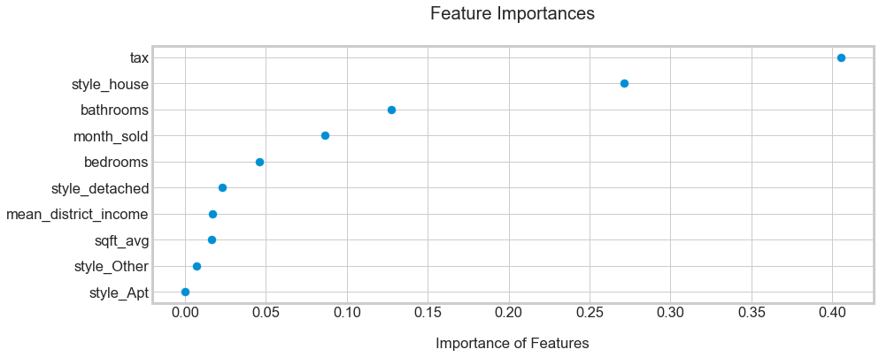

```python
from sklearn.ensemble import ExtraTreesRegressor

sns.set_style("whitegrid")
plt.figure(figsize=[13,5])
model = ExtraTreesRegressor(n_estimators=10)
model.fit(X_train, y_train)
# display the relative importance of each attribute

sorted_feature_importance = sorted(zip(model.feature_importances_, features.columns))

x = [a[0] for a in sorted_feature_importance]
y = [a[1] for a in sorted_feature_importance]

plt.scatter(x,y)
plt.xlabel('Importance of Features', labelpad=20)
plt.title('Feature Importances', pad=30)
plt.show()
```

"Cross correlation is a way to measure the degree of similarity between features. This type of correlation is useful to calculate because it can tell us if the values of one feature are predictive of the future values of another feature. Correlation matrix helps us to discover the bivariate relationship between independent variables in a dataset." The range of the correlation coefficient is from -1 to +1. The closer the cross-correlation value is to -1 or 1, the more closely the sets are co-related.

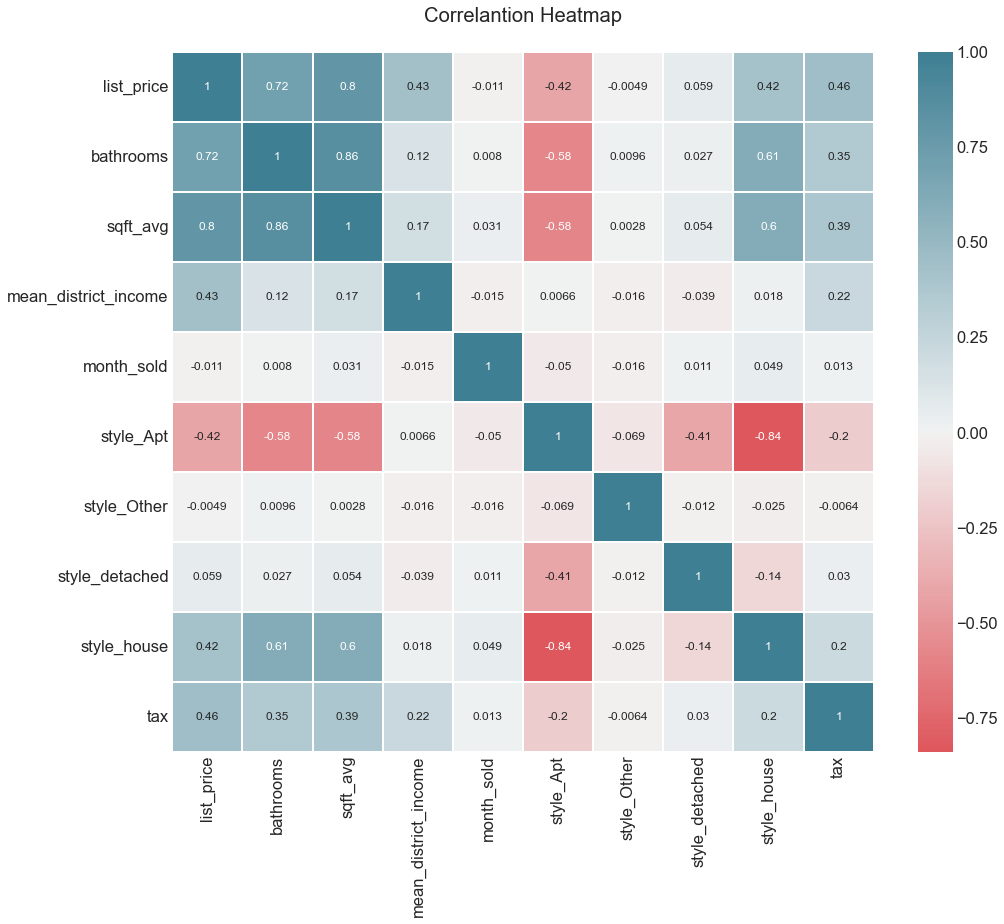

```python
# Create features Heatmap to see how feature are correlated with final_price
def correlantion_heatmap(df, center = None):
    fig, ax = plt.subplots(figsize = [14,12])
    colormap = sns.diverging_palette(11, 220, as_cmap=True)
    fig = sns.heatmap(df.corr(),
                cmap = colormap,
               center = center,
                annot = True,
                linewidths = 0.1,
                annot_kws={'fontsize':12})
    plt.title('Correlantion Heatmap', pad=30)

all_train = y_train.to_frame().join(X_train, how='left')
correlantion_heatmap(all_train, center=0)
```

To some extend there are co-relation between some features. For instance, the number of `bathrooms` and `sqft` are co-related. To have a better understanding of the data, let’s plot the sqft vs Housing price and `style` vs Housing price.

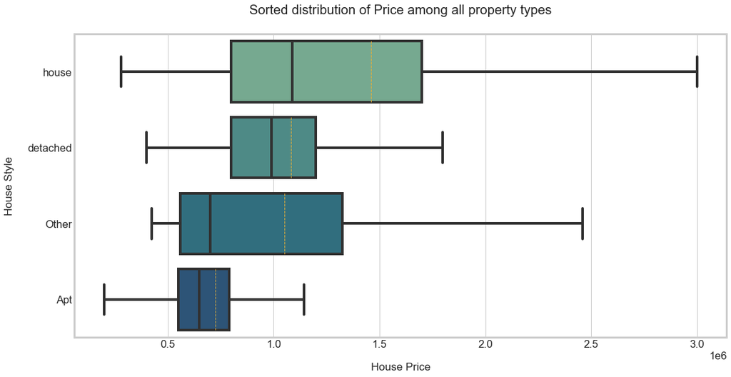

```python
# sns.set_style("whitegrid")
plt.subplots(figsize=[16,8])

sorted_medians = sorted([(houses_income[houses_income['style']==st].list_price.median(), st) for st in houses_income['style'].unique()], reverse=True)
sns.boxplot(y = 'style', x = 'list_price', data = houses_income, orient='h', showfliers=False, meanline =True, showmeans=True,
            order=[b for a,b in sorted_medians], palette="crest")

plt.xlabel('House Price', labelpad=20)
plt.ylabel('House Style', labelpad=20)
plt.title('Sorted distribution of Price among all property types', pad=30)
plt.show()
```

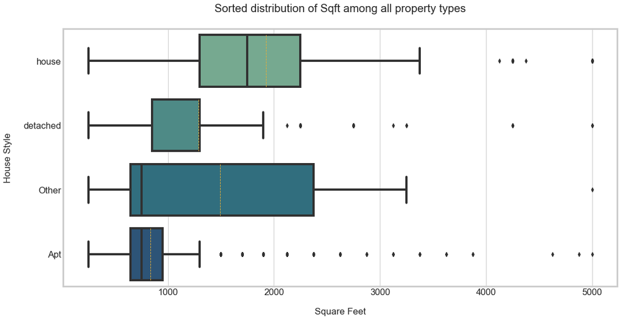

```python
plt.subplots(figsize=[16,8])

sorted_medians = sorted([(houses_income[houses_income['style']==st].sqft_avg.median(), st) for st in houses_income['style'].unique()], reverse=True)
sns.boxplot(y = 'style', x = 'sqft_avg', data = houses_income, orient='h', showfliers=True, meanline =True, showmeans=True,
           order=[b for a,b in sorted_medians], palette="crest")

plt.xlabel('Square Feet', labelpad=20)
plt.ylabel('House Style', labelpad=20)
plt.title('Sorted distribution of Sqft among all property types', pad=30)
plt.show()
```

## 7. House Price Prediction

First and foremost is the preprocessing of the data.

```python
print(X_train.dtypes)
print(X_test.dtypes)
print(y_train.dtypes)
print(y_test.dtypes)
```

```
bedrooms                category
bathrooms                float64
sqft_avg                 float64
mean_district_income       int64
month_sold                 int64
style_Apt                  uint8
style_Other                uint8
style_detached             uint8
style_house                uint8
tax                      float64
dtype: object
bedrooms                category
bathrooms                float64
sqft_avg                 float64
mean_district_income       int64
month_sold                 int64
style_Apt                  uint8
style_Other                uint8
style_detached             uint8
style_house                uint8
tax                       object
dtype: object
int64
int64
```

The data type in our dataset is different than each other. To ease the development of rigorous prediction algorithm, we are going to change all the data types to int64.

```python
X_train = X_train.astype('int64')
print(X_train.dtypes)

X_test = X_test.astype('int64')
print(X_test.dtypes)
```

```
bedrooms                int64
bathrooms               int64
sqft_avg                int64
mean_district_income    int64
month_sold              int64
style_Apt               int64
style_Other             int64
style_detached          int64
style_house             int64
tax                     int64
dtype: object
bedrooms                int64
bathrooms               int64
sqft_avg                int64
mean_district_income    int64
month_sold              int64
style_Apt               int64
style_Other             int64
style_detached          int64
style_house             int64
tax                     int64
dtype: object
```

### Data Normalization

Data normalisation is to reduce data redundancy and improve data integrity. Here we are using the `StandardScaler` function of SKlearn to do the data normalization.

```python
from sklearn import preprocessing

scaler = preprocessing.StandardScaler().fit(X_train)

X_train_scaled = scaler.transform(X_train)
X_test_scaled = scaler.transform(X_test)
```

### Training preliminary models as benchmark

At this stage, all the required elements to build the linear model are ready. The next step is to proceed building the preliminary model using scikit-learn module. Three different linear regression models were built and trained including OLS, Bayesian and Elastic Net. The process for all models were the same. To store the model algorithm, a variable is defined. Then, the train set variables was fitted into the model and the predictions were made.

```python
from sklearn.linear_model import LinearRegression # OLS algorithm
from sklearn.linear_model import BayesianRidge # Bayesian algorithm
from sklearn.linear_model import ElasticNet # ElasticNet algorithm


from sklearn.metrics import mean_squared_error # evaluation of errors
from sklearn.metrics import explained_variance_score as evs # evaluation metric
from sklearn.metrics import r2_score as r2 # evaluation metric
```

```python
# OLS
ols = LinearRegression()
ols.fit(X_train_scaled, y_train)
ols_yhat = ols.predict(X_test_scaled)
ols_test_error = mean_squared_error(y_test, ols_yhat)
print('OLS test RMSE: ${}'.format(ols_test_error))

# Bayesian
bayesian = BayesianRidge()
bayesian.fit(X_train_scaled, y_train)
bayesian_yhat = bayesian.predict(X_test_scaled)
bayesian_test_error = mean_squared_error(y_test, bayesian_yhat)
print('Bayesian test RMSE: ${}'.format(bayesian_test_error))

# ElasticNet
en = ElasticNet(alpha = 0.01)
en.fit(X_train_scaled, y_train)
en_yhat = en.predict(X_test_scaled)
en_test_error = mean_squared_error(y_test, en_yhat)
print('ElasticNet test RMSE: ${}'.format(en_test_error))
```

```
OLS test RMSE: $123322777829.73291
Bayesian test RMSE: $123337868887.263
ElasticNet test RMSE: $123470698458.30493
```

### Evaluation of benchmark models

When it comes to the ‘explained_variance_score’ metric, the score should not below 0.60 or 60%. If it is the case, then our built model is not sufficient for our data to solve the given case. So, the ideal score of the ‘explained_variance_score’ should be between 0.60 and 1.0.

```python
# estimate the explained variance score

print('EXPLAINED VARIANCE SCORE:')
print('-------------------------------------------------------------------------------')
print('Explained Variance Score of OLS model is {}'.format(evs(y_test, ols_yhat)))
print('-------------------------------------------------------------------------------')
print('Explained Variance Score of Bayesian model is {}'.format(evs(y_test, bayesian_yhat)))
print('-------------------------------------------------------------------------------')
print('Explained Variance Score of ElasticNet is {}'.format(evs(y_test, en_yhat)))
print('-------------------------------------------------------------------------------')
```

```
EXPLAINED VARIANCE SCORE:
-------------------------------------------------------------------------------
Explained Variance Score of OLS model is 0.7567294045845965
-------------------------------------------------------------------------------
Explained Variance Score of Bayesian model is 0.756701903738512
-------------------------------------------------------------------------------
Explained Variance Score of ElasticNet is 0.7564418598130314
-------------------------------------------------------------------------------
```

‘r2_score’ (R-squared) metric is the next evaluation metric that was used. R-squared is a measurement of how well the dependent variable explains the variance of the independent variable. R-squared is among the most popular evaluation metric for regression models. The suitable ‘r2_score’ should be at least 0.60.

```python
# estimate r-squared values
print('R-SQUARED:')
print('-------------------------------------------------------------------------------')
print('R-Squared of OLS model is {}'.format(r2(y_test, ols_yhat)))
print('-------------------------------------------------------------------------------')
print('R-Squared of Bayesian model is {}'.format(r2(y_test, bayesian_yhat)))
print('-------------------------------------------------------------------------------')
print('R-Squared of ElasticNet is {}'.format(r2(y_test, en_yhat)))
print('-------------------------------------------------------------------------------')
```

```
R-SQUARED:
-------------------------------------------------------------------------------
R-Squared of OLS model is 0.7566845629890284
-------------------------------------------------------------------------------
R-Squared of Bayesian model is 0.756654788381916
-------------------------------------------------------------------------------
R-Squared of ElasticNet is 0.756392716073014
-------------------------------------------------------------------------------
```

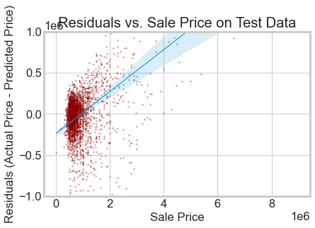

```python
residuals = y_test - bayesian_yhat

ax = sns.regplot(y_test, residuals,scatter_kws={"color":"darkred","alpha":0.3,"s":2},line_kws={'linewidth':1})
plt.ylim([-1000000, 1000000])
ax.set_xlabel('Sale Price')
ax.set_ylabel('Residuals (Actual Price - Predicted Price)')
ax.set_title("Residuals vs. Sale Price on Test Data");
```